Jaye Seawright

Evanston, IL · [Google Scholar](https://scholar.google.com/citations?user=dzSNGToAAAAJ)

# Representation, Democratic Crisis, and Multi-Method Research Design

Jaye Seawright is a professor of political science studying representation, democratic crisis, and multi-method research design.

[figure not shown]

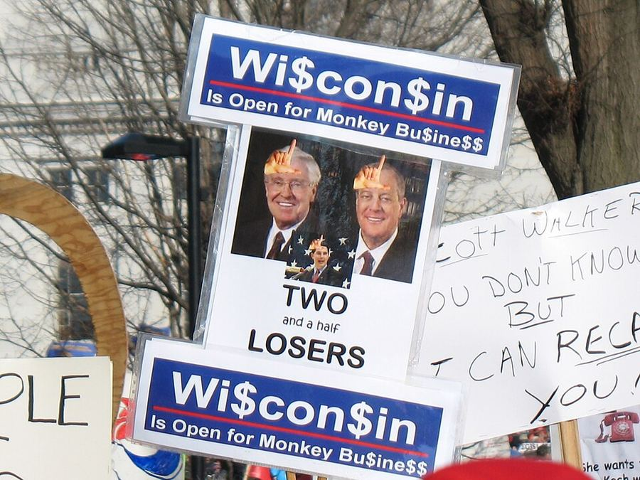

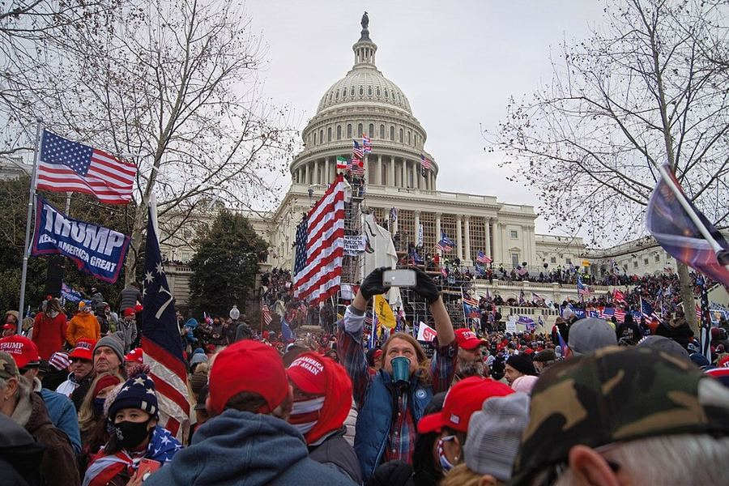

Party-system collapse: Caracas, 2004

Photos: [Carlos Granier-Phelps](https://commons.wikimedia.org/wiki/File:Anti-chavez_march.jpg) (CC BY-SA 2.5); Yuri Keegstra (CC BY-SA 2.0); Tyler Merbler (CC BY 2.0), via Wikimedia Commons.

Multi-method causal inference

Photos: [Carlos Granier-Phelps](https://commons.wikimedia.org/wiki/File:Anti-chavez_march.jpg) (CC BY-SA 2.5); Yuri Keegstra (CC BY-SA 2.0); Tyler Merbler (CC BY 2.0), via Wikimedia Commons.

Seawright has written about [party-system collapse and democratic crisis in Peru and Venezuela](https://www-sup.stanford.edu/books/title/?id=16821&bottom_ref=subject); about the participatory agendas of [wealthy people](https://www.cambridge.org/core/journals/perspectives-on-politics/article/abs/democracy-and-thepolicy-preferences-of-wealthy-americans/B783EEF6785FEE093198ABED8D2C3D61) and of [billionaires](https://press.uchicago.edu/ucp/books/book/chicago/B/bo29143391.html) in the U.S.; about [case selection](https://journals.sagepub.com/doi/abs/10.1177/1065912907313077) and other topics in [multi-method research design](https://www.cambridge.org/core/books/multimethod-social-science/286C2742878FBCC6225E2F10D6095A0C), among many other topics. Selected current projects are described on the Research page.

Seawright teaches a wide range of courses about social science research methods, giving students chances to use math, computers, reading, and critical thought to put claims about the political world in dialogue with evidence. See the Teaching page for course materials.

## Contact

j-seawright at northwestern dot edu

Office hours: Mondays, 3 to 5pm, 2001 Sheridan Road, Room 3203, or by arrangement, online or in person.

# Research

One project currently underway, followed by a selection of articles. A complete list, including book chapters and shorter pieces, is on [Google Scholar](https://scholar.google.com/citations?user=dzSNGToAAAAJ).

Comparative project · U.S. & Brazil

## The Politics of Extremism Behind January 6th and January 8th

An exploration, from multiple angles, of the extremism that enabled the congressional invasions of January 6th in the U.S. and January 8th in Brazil. Both invasions required thousands of people to choose an unusual and seemingly counterproductive act of political participation. With various collaborators, this project extends the literature on the traits of people who entered the U.S. Capitol, analyzes a large collection of podcast transcripts affiliated with movements central to the events, and examines public attitudes toward extremism and extremists. Each design will ultimately run in parallel in both countries, alongside an exploration of trans-national connections between right-wing movements there.

## Working Papers

Working paper · with Elizabeth Good

## Women of the Alt-Right: Constraints, Career Ambition, and Political Voice on U.S. Far-Right Talk-Show Media

Using an original dataset of several thousand transcribed alt-right podcast episodes and voice-based gender classification, compares how women and men talk on far-right shows. Argues that early-career women are constrained by traditional gender norms but also use those constraints to build a platform: either a "niche-to-platform" route (entering through stereotypically feminine topics before broadening into the movement's core issues) or a "credential-entry" route (arriving with pre-existing professional standing). Case studies and topic-association analysis across three far-right venues support the argument.

Working paper · sole author

## The Incentives for Risky Choices: Money, Fame, and Self-Damaging Acts on January 6th

Asks whether a search for notoriety or financial reward helps explain why Capitol rioters engaged in violence and openly documented it on social media. Using a panel of 1,036 charged defendants and multiple visibility measures (Google search interest, InfoWars mentions, the Congressional Record, and other right-wing outlets) estimated via three complementary panel/synthetic-control methods, finds a real boost in general-public visibility from participation but little evidence of elevated standing within right-wing media or elite circles. Crowdfunding data, by contrast, show a genuine financial payoff to violent participation, suggesting selective incentives may help explain risky behavior that day.

Working paper · with Arne Holverscheid and Jack McGovern

## Networks among Right-Wing Populist Heads of State: Qualitative and Statistical Evidence

Are right-wing nationalist leaders members of a paradoxical international alliance? Combines process tracing of face-to-face meetings and other ties among leaders with automated text analysis of an original corpus of speeches by six right-wing populist heads of government (Trump, Modi, Bolsonaro, Orbán, Meloni, and Milei) in their original languages. Multilingual sentence embeddings and topic models reveal a network of linguistic and ideological influence with first Bolsonaro and then Orbán at the center. Using qualitative evidence, argues that these links were deliberately constructed by the central figures through over a decade of shared conferences and institution-building, rather than parallel responses to similar events.

Working paper · with Arne Holverscheid

## Persuasion, Strategy, and the Microdynamics of Right-Wing Mainstreaming in the U.S.

Investigates why far-right media figures and Republican Party elites have grown closer over time. Using time-stamped corpora of far-right podcast transcripts and congressional floor speeches, applies topic modeling and time-series analysis to trace the direction of rhetorical influence between the two domains. Argues that far-right actors build mainstream ties by slowly developing a shared vocabulary: newer conservative politicians adopt far-right messaging on core populist themes, while more established conservatives use far-right media as a service provider to reach otherwise hard-to-reach audiences.

## Selected Publications

with Devin Caughey and Allan Dafoe · The Journal of Politics, 2017 · 79(2): 688–701

## [Nonparametric Combination (NPC): A Framework for Testing Elaborate Theories](https://doi.org/10.1086/689287)

Introduces a way to combine several hypothesis tests into a single overall inference without modeling the dependence among them, which is useful when a theory makes multiple predictions but the sample size is small, as in many field and natural experiments.

Sociological Methods & Research, 2016 · 45(3): 493–525

## [The Case for Selecting Cases That Are Deviant or Extreme on the Independent Variable](https://doi.org/10.1177/0049124116643556)

Using statistical modeling and simulation, argues that after a regression analysis, choosing cases with extreme scores on the independent variable, or genuinely deviant cases, is usually more useful for follow-up qualitative work than the more commonly recommended typical-case or most-similar-cases approaches.

with David Collier · Comparative Political Studies, 2014 · 47(1): 111–138

## [Rival Strategies of Validation: Tools for Evaluating Measures of Democracy](https://doi.org/10.1177/0010414013489098)

Compares four traditions for validating measures (levels-of-measurement, structural-equation modeling, the pragmatic tradition, and the case-based method) using cross-national measures of democracy as the test bed.

with Benjamin I. Page and Larry M. Bartels · Perspectives on Politics, 2013 · 11(1): 51–73

## [Democracy and the Policy Preferences of Wealthy Americans](https://doi.org/10.1017/S153759271200360X)

An original survey of top-wealth Americans finds their policy preferences frequently diverge from those of the average citizen, especially on taxation and social spending, raising questions about unequal political influence.

with Andrew Roberts and Jennifer Cyr · Comparative Political Studies, 2012 · 46(12): 1555–1581

## [Do Electoral Laws Affect Women's Representation?](https://doi.org/10.1177/0010414012463906)

Using within-country comparisons and matching methods, finds that switching to proportional representation boosts women's representation less consistently than earlier cross-national studies suggested.

with David Collier and Jody LaPorte · Political Research Quarterly, 2012 · 65(1): 217–232

## [Putting Typologies to Work: Concept Formation, Measurement, and Analytic Rigor](https://doi.org/10.1177/1065912912437162)

Defends typologies as rigorous analytic tools for concept formation and measurement against the charge that they are old-fashioned, and lays out standards for using them well.

with David Collier and Henry E. Brady · Political Analysis, 2010 · 18(4): 506–513

## [Outdated Views of Qualitative Methods: Time to Move On](https://doi.org/10.1093/pan/mpq022)

A response to a critic of "causal process observations," arguing that qualitative and quantitative evidence can be adjoined to strengthen causal inference, illustrated with examples including John Snow's classic study of cholera.

with John Gerring · Political Research Quarterly, 2008 · 61(2): 294–308

## [Case Selection Techniques in Case Study Research: A Menu of Qualitative and Quantitative Options](https://doi.org/10.1177/1065912907313077)

A widely cited menu of seven case-selection strategies for small-N research (typical, diverse, extreme, deviant, influential, most similar, and most different), each paired with a quantitative technique for identifying it within a larger dataset.

with Henry E. Brady and David Collier · Political Analysis, 2006 · 14(3): 353–368

## [Toward a Pluralistic Vision of Methodology](https://doi.org/10.1093/pan/mpj021)

Makes the case for a pluralistic view of causal-inference methods spanning the qualitative-quantitative divide, in dialogue with critics of *Rethinking Social Inquiry*.

Studies in Comparative International Development, 2005 · 40(1): 3–26

## [Qualitative Comparative Analysis vis-à-vis Regression](https://doi.org/10.1007/BF02686284)

Argues that Charles Ragin's Qualitative Comparative Analysis rests on assumptions about causation that are at least as demanding as those required by regression, undercutting a common claim that QCA needs fewer assumptions than statistical approaches.

Political Analysis, 2002 · 10(2): 178–193

## [Testing for Necessary and/or Sufficient Causation: Which Cases Are Relevant?](https://doi.org/10.1093/pan/10.2.178)

Shows that the standard advice to test necessary/sufficient-cause claims using only "positive" cases is unnecessarily restrictive, and that a design sampling from all cases is generally more statistically efficient.

# Books

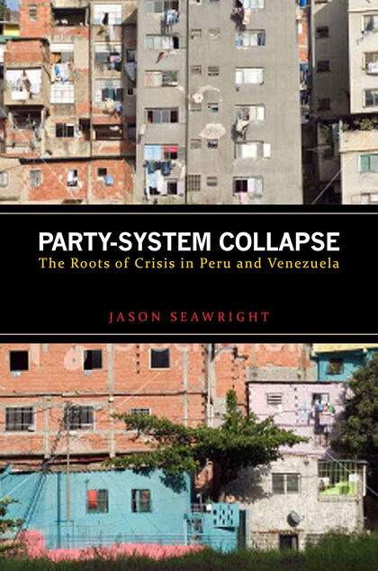

2012

[figure not shown]

2016

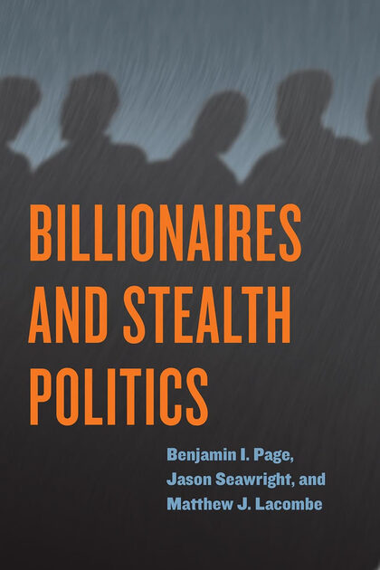

2018

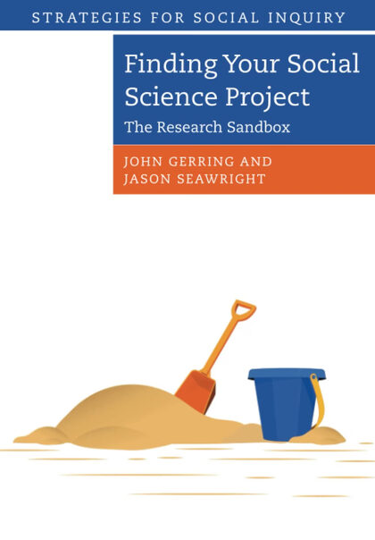

2022

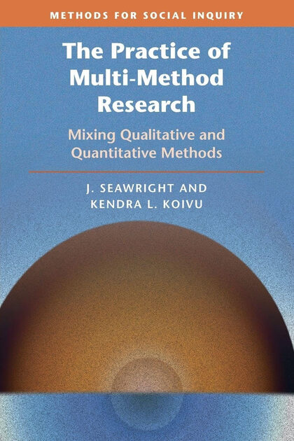

2026

Book · sole author · Stanford University Press, 2012

## [Party-System Collapse: The Roots of Crisis in Peru and Venezuela](https://www.amazon.com/dp/B009SNDFI4)

A comparative account of why the once-dominant party systems of Peru and Venezuela came apart in the 1980s and 1990s, and how the collapse in each country opened space for outsider figures, including, in Venezuela, Hugo Chávez.

Book · sole author · Cambridge University Press, 2016

## [Multi-Method Social Science: Combining Qualitative and Quantitative Tools](https://www.amazon.com/dp/B01L27MURA)

A systematic guide to designing multi-method research, built around the idea of integrative multi-method work: one method carries the main causal inference, while methods from other traditions test the assumptions that inference depends on. Covers statistical tools such as regression, matching, and natural experiments alongside qualitative tools such as process tracing and comparative case studies.

Book · with Benjamin I. Page and Matthew J. Lacombe · University of Chicago Press, 2018

## [Billionaires and Stealth Politics](https://www.amazon.com/dp/022658612X)

An account of how America's billionaires influence public policy on issues like taxation, immigration, and Social Security while rarely speaking publicly about those issues. The authors call this pattern "stealth politics" and explore what it means for democratic accountability.

Book · with John Gerring · Cambridge University Press, 2022

## [Finding Your Social Science Project: The Research Sandbox](https://www.amazon.com/dp/B0BG8ZB725)

A practical guide to the step methodological training usually skips: finding a topic in the first place. Covers strategies and heuristics for discovery, how data exploration can generate theory, and how to shape disparate ideas into a workable research question.

Book · with Kendra L. Koivu · Cambridge University Press

## [The Practice of Multi-Method Research](https://www.amazon.com/dp/100984959X)

A hands-on companion for actually carrying out multi-method designs, aimed at undergraduates preparing a thesis, graduate students designing a dissertation, and established scholars trying a new combination of methods for the first time. Includes exercises, data sets, and GitHub repositories to support self-teaching.

# Teaching

Courses on the empirical methods political scientists use to answer questions about politics, and why those methods matter.

PS 405 · Graduate · Winter 2026

## [Linear Models](https://github.com/jnseawright/ps405)

Northwestern's doctoral seminar in linear regression, part of the department's graduate methods requirement. Covers the derivation of ordinary least squares, model fit and multicollinearity, projection and influence, significance tests, multiple comparisons and statistical power, interactions, transformations, diagnostics, robust standard errors, and preparing regression tables.

PS 210 · Undergraduate · Fall 2026

## [Introduction to Empirical Methods in Political Science](https://github.com/jnseawright/ps210)

An introduction to the empirical methods political scientists use to answer questions about politics. Moves from asking good social science questions through causation, experiments, sampling and survey research, confidence intervals and significance tests, regression, statistical computing, machine learning, text as data, and qualitative methods.

PS 390 · Undergraduate · Winter 2027

## The Politics of the Far Right

A course on the global rise of the far right, drawing on political science, sociology, communication studies, and history to distinguish fascist, populist, and accelerationist movements and to interrogate what kind of explanation the far right actually requires: a recurrence of twentieth-century fascism or something new, a response to material conditions or to cultural and psychological forces, a product of elite strategy or of grassroots mobilization. Built around a term-long independent research project in which each student investigates a far-right movement of their choosing, culminating in an annotated bibliography, a presentation, and a final paper.

PS 312 · Undergraduate · Spring 2027

## [Statistical Research Methods](https://github.com/jnseawright/PS312)

A project-based course in which small groups design and carry out an original quantitative research project over the term. Working sessions build up through directed acyclic graphs, regression and control variables, natural experiments, difference-in-differences, synthetic control, regression-discontinuity designs, instrumental variables, missing data, and transparency practices, culminating in an in-class presentation of each group's findings.

PS 406 · Graduate students only · 2027

## [Quantitative Causal Inference](https://github.com/jnseawright/PS406)

A doctoral seminar on quantitative approaches to causal inference in the social sciences. Covers experiments, matching, natural experiments, instrumental variables, regression-discontinuity designs, difference-in-differences, synthetic control, and machine learning approaches to causal questions, with an emphasis on translating between mathematical and applied descriptions of each estimator.

# CV

The current curriculum vitae is available as a PDF.

Download CV (PDF)